# Question

A downward-facing [parabola](https://en.wikipedia.org/wiki/Parabola) $f$ is defined below.

$$f(x)~=~-x^{2}+{8}x-{11}$$

An upwards-facing parabola, $g$, is constructed such that $g$ and $f$ are mirror images with a shared vertex, as shown in the graph below.

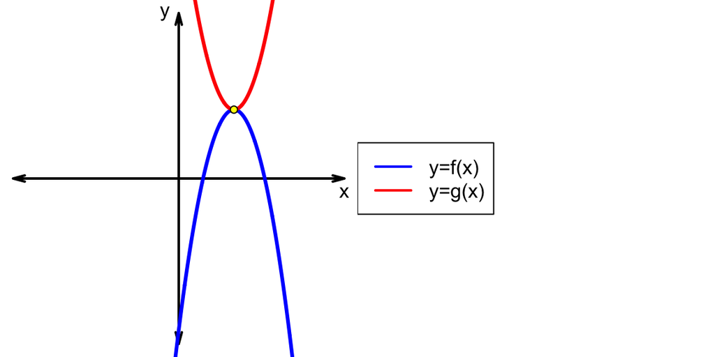

The second parabola, $g$, can be written in standard form with two parameters ($B$ and $C$).

$$g(x)~=~x^2+Bx+C$$

Find $B$ and $C$.

- $B~=~$##ANSWER1##
- $C~=~$##ANSWER2##

## Answerlist

- -18
- -16
- -10
- -8
- -4
- 4
- 8
- 10
- 16
- 18
- -86
- -76
- -21
- -11
- -10
- -2
- 2
- 10
- 11
- 21
- 76
- 86

# Solution

1. Find the vertex by completing the square. *(First factor out the negative to get a quadratic polynomial with a +1 leading coefficient.)*

$$f(x)~=~-\left(x^{2}-{8}x+{11}\right)$$

$$\left(\frac{-8}{2}\right)^2~=~16$$

$$f(x)~=~-\left(x^{2}-{8}x+{16}+{11}-{16}\right)$$

$$f(x)~=~-\left( (x-{4})^2-{5}
\right)$$

$$f(x)~=~-(x-{4})^2+{5}$$

2. The second parabola has the same vertex $(4,5)$, but it faces upwards. The general vertex form is $A(x-h)^2+k$. If $A$ is positive, the parabola faces upward, and if $A$ is negative, the parabola faces downward. If $|A|>1$, then the parabola gets stretched vertically. If $|A|<1$, then the parabola gets squished vertically. Anyway, in this case, we just need to switch the sign of $A$.

$$g(x)~=~(x-{4})^2+{5}$$

3. Expand to produce standard form.

$$g(x)~=~x^{2}-{8}x+{16}+{5}$$

$$g(x)~=~x^{2}-{8}x+{21}$$

# Meta-information

extype: cloze exclozetype: schoice|schoice exsolution: 0001000000|000000000100 exname: flip_parabola